# Latent Dirichlet Allocation

Ashwin Malshe

14 February 2020

# Topic Modeling

Topic modeling allows us to identify topics embedded in the textual data. The assumption is that each text document is composed of one or more topics, which are latent. The job of a topic model then is to extract the topics from text. In this chapter we will use a popular probabilistic model called Latent Dirichlet Allocation (LDA) first introduced by Blei, Ng, and Jordan (2003). LDA is a unsupervised machine learning method as we don’t know the target variable (i.e., the latent topic) ex ante.

Latent Dirichlet Allocation, Journal of Machine Learning Research, 3, 993–1022.

## Latent Dirichlet Allocation

Imagine that you are in your dentist’s waiting room. You pick up a magazine and casually start browsing it. While eyeballing text on random pages, you came across the following text:

*Williamson and Taylor then began to reap the rewards of their patience and accelerated their way to an immensely productive partnership of 160 from 28.5 overs before Taylor chipped to Jason Holder at mid-on off the bowling of Chris Gayle to depart for 69. Williamson remained steady as ever and went on to record his second consecutive hundred, following on from his knock against South Africa on Wednesday. The Kiwi skipper eventually fell for 148, amassing over half of his side’s final total of 291. Cottrell was West Indies’ leading man, finishing with figures of 4/56.*

*With Evin Lewis suffering an injury to his hamstring, Shai Hope joined Chris Gayle at the crease to begin the chase, but the right-hander perished early to Trent Boult, and Nicholas Pooran followed him back to the sheds not long after. Gayle took a liking to Matt Henry’s bowling and his partnership with Shimron Hetmyer – featuring some monstrous sixes – saw West Indies take control of the match. The game then swung back in the Black Caps’ favour as Lockie Ferguson interrupted with the removal of Hetmyer with an incredible slower ball that initiated a collapse of five wickets for 22 runs.*

Source: https://www.cricketworldcup.com/news/en/1253879

Note that in order to determine the topic underlying the text, you used some of the words in the text. In an article that describes a game of Cricket, it is likely that the article will use words associated with Cricket. However, some of these words also may appear in an article about Baseball. So there is some uncertainty in your mind about the topic of the text. You decide to assign 60-40 probabilities to Cricket and Baseball.

LDA works on a similar principle. It assumes a data generating process under which a document is generated based on a mix of latent topics and the words that pertain to those topics. As such LDA treats an article as a “bag of words”. LDA ignores the ordering of those words. Thus, for LDA both these sentences are the same:

*Williamson remained steady as ever and went on to record his second consecutive hundred, following on from his knock against South Africa on Wednesday.*

and

*steady remained Williamson as ever and record on to went his hundred second consecutive Wednesday against Africa South on, knock following on from his.*

LDA assumes that each document has a set of topics, which follow multinomial logistic distribution. However, the probabilities of the multinomial model are not fixed for all the documents. LDA assumes that the distribution of probabilities follow Dirichlet distribution. Thus, for each document, the topics are random draws from a multinomial distribution. The probabilities of the multinomial distribution are in turn are random draws from Dirichlet distribution. The choice of this distribution is due to mathematical convenience as Dirichlet distribution is a conjugate prior to multinomial logistic distribution. As a result, the *posterior* distribution of the probability distribution is Dirichlet too. This significantly simplifies the inference problem.

For a partial mathematical treatment please refer to the original paper cited above.

Our task in topic modeling using LDA can be broken down into the following steps:

1. Create a corpus of multiple text documents.
2. Preprocess the text to remove numbers, stop words, punctuation, etc. Additionally, use stemming.
3. Decide the number of topics and fit LDA on the corpus. The number of topics is a hyperparameter to tune.
4. Get the most common words defining each topic. Give them meaningful labels.

## Data

Load/install the packages as follows.

**In the classroom if `qdap` fails to install, ignore it for the time being.**

```r
pacman::p_load(dplyr,       # For data wrangling
               ggplot2,     # For plotting
               readr,       # For reading csv files
               tm,          # For textmining
               topicmodels, # For LDA
               qdap,        # For some text cleaning
               caret,       # For random forest
               SnowballC,   # Used by tm package internally
               tint         # Document theme for the output HTML file
               )
```

We will use a Kaggle dataset consisting of 34,000 Amazon product reviews such as Kindle, Fire TV Stick, etc., provided by Datafiniti: https://www.kaggle.com/datafiniti/consumer-reviews-of-amazon-products

I have already downloaded `1429_1.csv` file. We read this file using `read_csv()` function from `readr` package.

```r
reviews <- read_csv("1429_1.csv")
```

Take a look at the column names

```r
names(reviews)
```

```
##  [1] "id"                   "name"                 "asins"
##  [4] "brand"                "categories"           "keys"
##  [7] "manufacturer"         "reviews.date"         "reviews.dateAdded"
## [10] "reviews.dateSeen"     "reviews.didPurchase"  "reviews.doRecommend"
## [13] "reviews.id"           "reviews.numHelpful"   "reviews.rating"
## [16] "reviews.sourceURLs"   "reviews.text"         "reviews.title"
## [19] "reviews.userCity"     "reviews.userProvince" "reviews.username"
```

We are interested in `reviews.text`. Next we will delete all the rows where the number of words in the reviews were less than 20. You can change this number to something else depending on your application.

**Don’t run this chunk if you could not install `qdap`**

```r
reviews <- reviews %>%
  filter(qdap::word_count(.$reviews.text, byrow = TRUE) >= 20)

# Print number of rows
nrow(reviews)
```

```
## [1] 18122
```

We are left with 18,122 rows.

## Pre-processing

We will extract only the review text.

```r
review_text <- reviews %>%
  pull(reviews.text)
```

### Get stop words

Load stop words and take a look at first 10 stop words

```r
my_stopwords <- readRDS("my-stopwords.rds")

head(my_stopwords, 10)
```

```
##  [1] "a"       "about"   "above"   "after"   "again"   "against" "ain"
##  [8] "all"     "am"      "an"
```

### `tm` package

`tm` is a powerful package for text processing. For it to operate, we will first create a corpus of all the documents. Next, we will use `tm_map` function to remove stop words, numbers, punctuation, white space. Finally we will also stem the words.

```r
rev_corpus <- tm::Corpus(VectorSource(review_text)) %>%
  tm_map(content_transformer(tolower)) %>%
  tm_map(removeWords, c(my_stopwords, "amazon")) %>%
  tm_map(removeNumbers) %>%
  tm_map(stripWhitespace) %>%
  tm_map(removePunctuation, preserve_intra_word_dashes = TRUE)%>%
  tm_map(stemDocument)
```

## Document term matrix

Thus, if a word appears in less than 100 documents or more than 1000 documents, we will drop it.

```r
dtm <- rev_corpus %>%
  DocumentTermMatrix(control = list(bounds = list(global = c(100, 1000))))

# Print matrix dimension
dim(dtm)
```

```
## [1] 18122   432
```

With this, we have just 432 words left in the DTM. Perhaps this is too small for the analysis. If you feel so, you could change the bounds.

### Remove empty documents

For a few documents, all the frequencies in the corresponding rows are 0. We will get rid of these documents. First, we create an index which will hold the information on the rows to keep. This will be a logical vector. Check how many rows we will keep.

```r
index_kp <- rowSums(as.matrix(dtm)) > 0

# Print out the number of rows to keep.
sum(index_kp)
```

```
## [1] 17992
```

So, we are dropping 18,122 - 17,992 = 130 documents. Next, we will adjust `dtm` and `review_text` so that they each have 17,992 rows/elements.

```r
dtm <- dtm[index_kp, ]
review_text <- review_text[index_kp]
```

## Fitting the LDA

Now we are ready to fit LDA on our text. For this we will use `dtm`. We have to decide on the number of topics. As this is a hyperparameter we have to tune, we can use a grid search. The optimum value of number of topics will give us the maximum likelihood. I don’t go into the details of this, but if you are interested, I recommend checking out Martin Ponweiser’s thesis where he provides the method and the R code to do this [PDF]: http://epub.wu.ac.at/3558/1/main.pdf.

`LDA()` gives us the method choice between Variational Expectation-Maximization (VEM) algorithm and Gibb’s sampler. We will use the latter. We select `alpha` equal to 0.2. Lower values of `alpha` lead to selecting only a few topics per document. Higher values of `alpha` give us diffused distribution. This is also a hyperparameter you might want to tune using grid search. We select 2,000 iterations out of which the first 1,000 are not used (that’s why “burn-in”).

The following code took about 30 seconds on my computer.

```r
lda_model <- LDA(x = dtm,
                 k = 20,
                 method = "Gibbs",
                 control = list(seed = 5648,
                                alpha = 0.2,
                                iter = 2000,
                                burnin = 1000)
                 )
```

## LDA output

Now we are ready to see the words associated with each of the 20 topics. Recall that we used stemming, which means some of the words will be difficult to read. We print first 10 words for each topic using `terms()` function.

```r
terms(lda_model, 10)
```

```
##       Topic 1   Topic 2    Topic 3    Topic 4     Topic 5   Topic 6
##  [1,] "control" "card"     "christma" "speaker"   "batteri" "cabl"
##  [2,] "smart"   "memori"   "friend"   "sound"     "life"    "stream"
##  [3,] "voic"    "download" "happi"    "qualiti"   "long"    "box"
##  [4,] "hous"    "storag"   "wife"     "dot"       "charg"   "netflix"
##  [5,] "turn"    "movi"     "user"     "tap"       "last"    "roku"
##  [6,] "command" "add"      "enjoy"    "bluetooth" "hour"    "appl"
##  [7,] "room"    "expand"   "daughter" "voic"      "week"    "remot"
##  [8,] "phone"   "space"    "mother"   "portabl"   "day"     "prime"
##  [9,] "integr"  "featur"   "mom"      "listen"    "longer"  "content"
## [10,] "autom"   "micro"    "like"     "connect"   "month"   "cut"
##       Topic 7    Topic 8     Topic 9  Topic 10     Topic 11    Topic 12
##  [1,] "email"    "version"   "day"    "question"   "stick"     "charg"
##  [2,] "internet" "model"     "want"   "answer"     "box"       "problem"
##  [3,] "web"      "cover"     "order"  "fun"        "faster"    "connect"
```

[output cut: 29 more lines]

## Topic distribution

We can get some idea about the incidence of each topic in the corpus by looking at the average posterior distribution of the topics. This is arguably a crude way. We can also plot the probability distributions.

For this, we first need to get the posterior distributions of $\theta$. The function `posterior()` returns posteriors of both $\theta$ and $\beta$. Whereas $\theta$ is the posterior distribution of the topics, $\beta$ is the posterior distributions of the words or terms.

```r
lda_post <- posterior(lda_model)
theta <- lda_post$topics
beta <- lda_post$terms
```

Let’s take a look at the average probability of each topic across all the documents.

```r
colMeans(theta)
```

```
##          1          2          3          4          5          6          7
## 0.05055900 0.04734300 0.05441513 0.05023523 0.04581786 0.05049758 0.04906735
##          8          9         10         11         12         13         14
## 0.05059388 0.04910767 0.05161731 0.04850895 0.04609351 0.05392390 0.05323851
##         15         16         17         18         19         20
## 0.05411623 0.05009309 0.04859859 0.04865923 0.04927545 0.04823855
```

We see that the average topic incidence is pretty much uniform across the documents. Of course, this hides all the variation. Perhaps it is easier to look at the plots of probabilities.

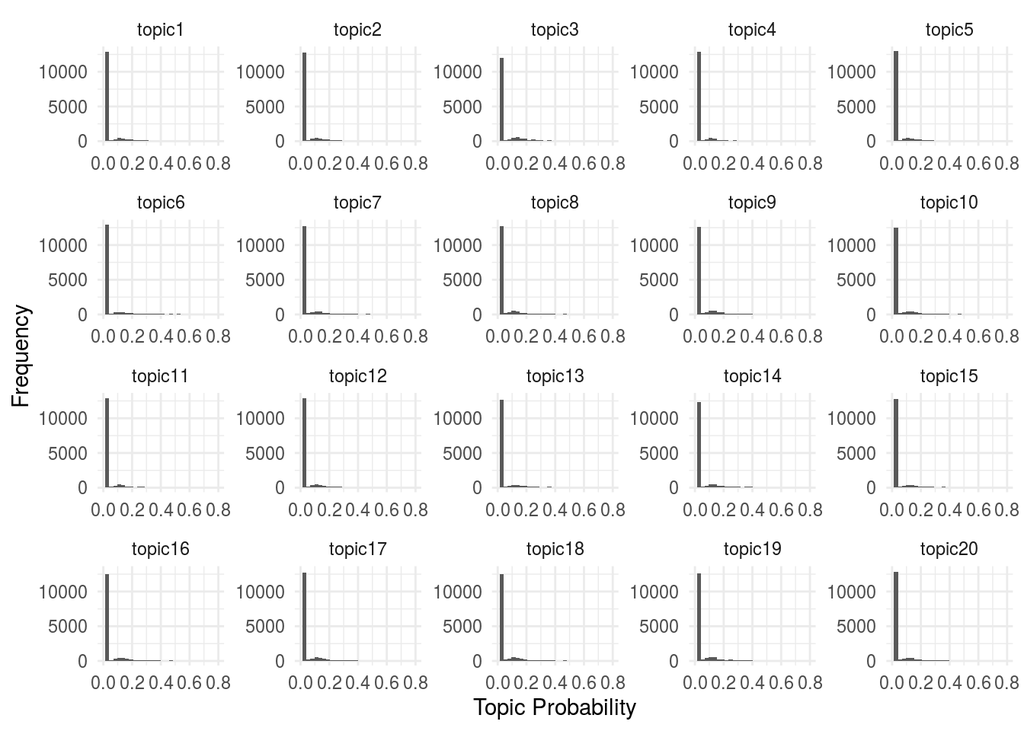

```r
theta %>%
  as.data.frame() %>%
  rename_all(~ paste0("topic", 1:20)) %>%
  reshape2::melt() %>%
  ggplot(aes(value)) +
  geom_histogram() +
  scale_x_continuous(limits = c(0, 0.8)) +
  scale_y_continuous(limits = c(0, 13000)) +
  facet_wrap(~ variable, scales = "free") +
  labs(x = "Topic Probability", y = "Frequency") +
  theme_minimal()
```

## Summary

In this chapter we learned how to fit Latent Dirichlet Allocation model on textual data. We used Amazon product reviews data from Kaggle and identified 20 topics from the review text. In this example, we used a fixed number of topics. Ideally, we would like to tune this hyperparameters. The chapter references the method to find the optimum number of topics.